# Perspectives on Romantic Relationships

- Show All Code
- Hide All Code
- View Source

PSY 120L Reproducible Analysis Report

Author

Breeanna Pernas

Published

June 7, 2026

## About This Report

This is a analytic report that will explore perspectives on romantic relationships.

## Study Overview

The purpose of our study is to examine whether the opinions of one’s family and friends affect relationship satisfaction and commitment, depending on individual susceptibility to interpersonal influence.

## Setup and Software Environment

The following packages were used for data preparation, scale construction, statistical modeling, and post hoc comparisons

**Load Packages**

```r
library(tidyverse)  # data manipulation + plotting
library(psych)      # scale construction + reliability
library(afex)       # ANOVA models + effect sizes
library(emmeans)    # estimated marginal means + confidence intervals
```

## Data Source and Analysis Dataset

This section loads the survey dataset, verifies that it imported correctly, and defines the set of variables that will be used in the analyses.

### Import Dataset

```r
study_raw <- read_csv("data/relationships_data.csv")
```

### Check Imported Dataset

```r
dim(study_raw)
```

```
[1] 75 41
```

```r
names(study_raw)
```

```
 [1] "StartDate"             "EndDate"               "Status"
 [4] "IPAddress"             "Progress"              "Duration (in seconds)"
 [7] "Finished"              "RecordedDate"          "ResponseId"
[10] "ExternalReference"     "LocationLatitude"      "LocationLongitude"
[13] "DistributionChannel"   "UserLanguage"          "Q34"
[16] "ras1"                  "ras2"                  "ras3"
[19] "ras4"                  "ras5"                  "ras6"
[22] "ras7"                  "commit1"               "commit2"
[25] "commit3"               "commit4"               "commit5"
[28] "commit6"               "commit7"               "suscep1"
[31] "suscep2"               "suscep3"               "suscep4"
[34] "suscep5"               "suscep6"               "suscep7"
[37] "suscep8"               "age"                   "gender"
[40] "relationship"          "condition"
```

```r
head(study_raw)
```

```
# A tibble: 6 × 41
  StartDate    EndDate Status IPAddress Progress Duration (in seconds…¹ Finished
  <chr>        <chr>    <dbl> <chr>        <dbl>                  <dbl>    <dbl>
1 5/5/26 19:11 5/5/26…      0 174.194.…      100                    312        1
2 5/5/26 20:05 5/5/26…      0 72.205.8…      100                    188        1
3 5/5/26 20:15 5/5/26…      0 165.85.5…      100                    150        1
4 5/5/26 20:34 5/5/26…      0 172.226.…      100                    187        1
5 5/5/26 21:23 5/5/26…      0 174.221.…      100                    280        1
6 5/5/26 21:22 5/5/26…      0 108.147.…      100                    455        1
# ℹ abbreviated name: ¹`Duration (in seconds)`
# ℹ 34 more variables: RecordedDate <chr>, ResponseId <chr>,
#   ExternalReference <lgl>, LocationLatitude <dbl>, LocationLongitude <dbl>,
#   DistributionChannel <chr>, UserLanguage <chr>, Q34 <dbl>, ras1 <dbl>,
#   ras2 <dbl>, ras3 <dbl>, ras4 <dbl>, ras5 <dbl>, ras6 <dbl>, ras7 <dbl>,
#   commit1 <dbl>, commit2 <dbl>, commit3 <dbl>, commit4 <dbl>, commit5 <dbl>,
#   commit6 <dbl>, commit7 <dbl>, suscep1 <dbl>, suscep2 <dbl>, …
```

Above is to visually confirm the dataset and identifying its study’s variables.

### Create Analysis Dataset

```r
study_vars <- c(

study_vars <- c(
  "condition",  # experimental condition variable
  "age", "gender", "relationship",

      "ras1", "ras2","ras3","ras4","ras5","ras6","ras7",

      "commit1","commit2","commit3","commit4","commit5","commit6","commit7",

      "suscep1","suscep2","suscep3","suscep4","suscep5","suscep6","suscep7","suscep8"

)
)


study_data <- study_raw %>%
  select(all_of(study_vars)) %>%
  mutate(across(everything(), as.numeric))
```

### Check Analysis Dataset

```r
length(study_vars)
```

```
[1] 26
```

```r
dim(study_data)
```

```
[1] 75 26
```

```r
names(study_data)
```

```
 [1] "condition"    "age"          "gender"       "relationship" "ras1"
 [6] "ras2"         "ras3"         "ras4"         "ras5"         "ras6"
[11] "ras7"         "commit1"      "commit2"      "commit3"      "commit4"
[16] "commit5"      "commit6"      "commit7"      "suscep1"      "suscep2"
[21] "suscep3"      "suscep4"      "suscep5"      "suscep6"      "suscep7"
[26] "suscep8"
```

Above is verifying that the analysis dataset is correct.

## Variable Preparation

This section converts the imported survey data into an analysis-ready dataset. Variable types are corrected as needed, categorical variables are prepared for analysis, scale items are verified and reverse-coded where appropriate, scale scores are computed, and a median split is applied to the SUSCEP scale to define analysis groups for the ANOVA models.

### Prepare Participant ID and Experimental Condition

```r
study_data <- study_data %>%
  mutate(
    id = row_number(),
    condition = factor(
      condition,
      levels = c(0, 1),
      labels = c("Low Social Approval", "High Social Approval")
    )
  )
```

This section is to overwrite the variable to keep the workflow streamlined and so the labeled version is used consistently in all of the analyses and figures.

### Check Experimental Condition Coding

```r
study_data %>%
  count(condition) %>%
  knitr::kable(
    col.names = c("Condition", "n")
  )
```

| Condition | n |
| --- | --- |
| Low Social Approval | 38 |
| High Social Approval | 37 |

This verifies that the condition labels match the original coding.The distribution of participants across social approval conditions reflects the original coding and shows minor imbalance due to missing data or earlier exclusions.

### Check Prepared Analysis Dataset

```r
dim(study_data)
```

```
[1] 75 27
```

```r
names(study_data)
```

```
 [1] "condition"    "age"          "gender"       "relationship" "ras1"
 [6] "ras2"         "ras3"         "ras4"         "ras5"         "ras6"
[11] "ras7"         "commit1"      "commit2"      "commit3"      "commit4"
[16] "commit5"      "commit6"      "commit7"      "suscep1"      "suscep2"
[21] "suscep3"      "suscep4"      "suscep5"      "suscep6"      "suscep7"
[26] "suscep8"      "id"
```

Final checks were conducted to confirm that the dataset now contains only participant responses, that variable types are appropriate for analysis, and that variable names remain consistent with the Master Key.

### Reverse-Code Scale Items

Items requiring reverse coding were transformed so that higher values consistently reflect more of the underlying construct. All reverse coding was completed prior to scale score computation to ensure consistency across analyses.

```r
# Reverse-code selected RAS items
study_data <- study_data %>%
  mutate(
    ras4_r = 6 - ras4, # reverse-codes ras4
    ras7_r = 6 - ras7, # reverse-codes ras7

    commit4_r = 8 - commit4, # reverse-codes commit4
    commit5_r = 8 - commit5 # reverse-codes commit5
  )
```

### Check Reverse Coding

```r
study_data %>%
  select(ras4_r, ras4, commit4_r, commit4) %>%
  head(10) %>%
  knitr::kable()
```

| ras4_r | ras4 | commit4_r | commit4 |
| --- | --- | --- | --- |
| 4 | 2 | 6 | 2 |
| 4 | 2 | 6 | 2 |
| 4 | 2 | 6 | 2 |
| 4 | 2 | 2 | 6 |
| 5 | 1 | 6 | 2 |
| 5 | 1 | 7 | 1 |
| 3 | 3 | 3 | 5 |
| 4 | 2 | 6 | 2 |
| 5 | 1 | 7 | 1 |
| 5 | 1 | 7 | 1 |

### Create Scale Scores

Explicit item lists were created for each of the three scales to make scale construction transparent and to prevent accidental inclusion or exclusion of items.

```r
# Relationship Assessment Scale items
ras_items <- c(
  "ras1",
  "ras2",
  "ras3",
  "ras4_r",
  "ras5",
  "ras6",
  "ras7_r"
)

# Rusbult Commitment Scale items
commit_items <- c(
  "commit1",
  "commit2",
  "commit3",
  "commit4_r",
  "commit5_r",
  "commit6",
  "commit7"
)

# Susceptibility Scale items
suscep_items <- c(
  "suscep1",
  "suscep2",
  "suscep3",
  "suscep4",
  "suscep5",
  "suscep6",
  "suscep7",
  "suscep8"
)


study_data <- study_data %>%
  mutate(
    ras_scale = rowMeans(across(all_of(ras_items)), na.rm = TRUE),
    commit_scale = rowMeans(across(all_of(commit_items)), na.rm = TRUE),
    suscep_scale = rowMeans(across(all_of(suscep_items)), na.rm = TRUE)
  )
```

### Check Scale Scores

```r
study_data %>%
  select(ras_scale, commit_scale, suscep_scale) %>%
  summary()
```

```
   ras_scale      commit_scale    suscep_scale
 Min.   :2.286   Min.   :2.857   Min.   :1.375
 1st Qu.:3.714   1st Qu.:4.857   1st Qu.:3.250
 Median :4.143   Median :6.000   Median :4.250
 Mean   :4.109   Mean   :5.718   Mean   :4.137
 3rd Qu.:4.714   3rd Qu.:6.714   3rd Qu.:4.938
 Max.   :5.000   Max.   :7.000   Max.   :6.625
```

```r
study_data %>%
  summarise(
    ras_missing = mean(is.na(ras_scale)),
    commit_missing = mean(is.na(commit_scale)),
    suscep_missing = mean(is.na(suscep_scale))
  ) %>%
  knitr::kable()
```

| ras_missing | commit_missing | suscep_missing |
| --- | --- | --- |
| 0 | 0 | 0 |

Verifying that there are no missing scores or variables.

### Create Susceptibility Groups

A categorical susceptibility grouping variable was created from the susceptibility scale score to support the planned 2 × 2 ANOVA models.

```r
suscep_median <- median(study_data$suscep_scale, na.rm = TRUE)

study_data <- study_data %>%
  mutate(
    suscep_msplit = if_else(suscep_scale <= suscep_median, "Low", "High"),
    suscep_msplit = factor(suscep_msplit, levels = c("Low", "High"))
  )

suscep_median
```

```
[1] 4.25
```

```r
study_data %>%
  count(suscep_msplit) %>%
  knitr::kable()
```

| suscep_msplit | n |
| --- | --- |
| Low | 38 |
| High | 37 |

The median split produces two groups (Low vs High Susceptibility).

### Check Scale Reliability

Internal consistency was evaluated for each scale using Cronbach’s alpha (α) and McDonald’s omega (ω).

```r
# Create item-only data frames for each scale
ras_item_df <- study_data %>% select(all_of(ras_items))
commit_item_df <- study_data %>% select(all_of(commit_items))
suscep_item_df <- study_data %>% select(all_of(suscep_items))

# Compute internal consistency estimates
ras_alpha <- psych::alpha(ras_item_df)
ras_omega <- psych::omega(ras_item_df, plot = FALSE)

commit_alpha <- psych::alpha(commit_item_df)
commit_omega <- psych::omega(commit_item_df, plot = FALSE)

suscep_alpha <- psych::alpha(suscep_item_df)
suscep_omega <- psych::omega(suscep_item_df, plot = FALSE)

# Print only alpha and omega coefficients
tibble(
  scale = c("Relationship Assessment", "Commitment", "Susceptibility"),
  alpha = c(
    ras_alpha$total$raw_alpha,
    commit_alpha$total$raw_alpha,
    suscep_alpha$total$raw_alpha
  ),
  omega = c(
    ras_omega$omega.tot,
    commit_omega$omega.tot,
    suscep_omega$omega.tot
  )
)
```

```
# A tibble: 3 × 3
  scale                   alpha omega
  <chr>                   <dbl> <dbl>
1 Relationship Assessment 0.916 0.939
2 Commitment              0.918 0.950
3 Susceptibility          0.874 0.913
```

The susceptibility scale showed strong internal consistency in this sample (α = .87, ω = .91).

## Descriptive Statistics

This section summarizes the distribution of the susceptibility, relationship satisfaction, and commitment scale scores and describes the sex composition of the sample prior to hypothesis testing.

```r
study_data %>%
  select(
    ras_scale,
    commit_scale,
    suscep_scale
  ) %>%
  psych::describe() %>%
  knitr::kable(digits = 2)
```

|  | vars | n | mean | sd | median | trimmed | mad | min | max | range | skew | kurtosis | se |
| --- | --- | --- | --- | --- | --- | --- | --- | --- | --- | --- | --- | --- | --- |
| ras_scale | 1 | 75 | 4.11 | 0.69 | 4.14 | 4.16 | 0.64 | 2.29 | 5.00 | 2.71 | -0.66 | -0.34 | 0.08 |
| commit_scale | 2 | 75 | 5.72 | 1.12 | 6.00 | 5.82 | 1.27 | 2.86 | 7.00 | 4.14 | -0.67 | -0.58 | 0.13 |
| suscep_scale | 3 | 75 | 4.14 | 1.18 | 4.25 | 4.17 | 1.11 | 1.38 | 6.62 | 5.25 | -0.28 | -0.52 | 0.14 |

Descriptive statistics above were computed for the susceptibility, relationship satisfaction, and commitment scale scores.

### Sample Composition by Age, Gender, and Relationship

```r
study_data %>%
  summarise(
    mean_age = mean(age, na.rm = TRUE),
    sd_age = sd(age, na.rm = TRUE),
    min_age = min(age, na.rm = TRUE),
    max_age = max(age, na.rm = TRUE)
  ) %>%
  knitr::kable(
    digits = 2,
    col.names = c("Mean", "SD", "Minimum", "Maximum"),
    caption = "Sample Age: Mean, Standard Deviation, and Range"
  )
```

Sample Age: Mean, Standard Deviation, and Range

| Mean | SD | Minimum | Maximum |
| --- | --- | --- | --- |
| 26.33 | 12.9 | 19 | 73 |

```r
study_data %>%
  count(gender) %>%
  arrange(gender) %>%
  mutate(percent = round(100 * n / sum(n), 1)) %>%
  knitr::kable(
    col.names = c("Gender", "n", "Percent"),
    caption = "Sample Composition by Gender"
  )
```

Sample Composition by Gender

| Gender | n | Percent |
| --- | --- | --- |
| 1 | 15 | 20 |
| 2 | 60 | 80 |

```r
study_data %>%
  count(relationship) %>%
  arrange(relationship) %>%
  mutate(percent = round(100 * n / sum(n), 1)) %>%
  knitr::kable(
    col.names = c("Relationship", "n", "Percent"),
    caption = "Sample Composition by Year"
  )
```

Sample Composition by Year

| Relationship | n | Percent |
| --- | --- | --- |
| 1 | 29 | 38.7 |
| 2 | 43 | 57.3 |
| 3 | 3 | 4.0 |

The age, gender, and relationship composition of the sample was summarized using counts and percentages.

The sample was unevenly split by sex, with 80% identifying as female (n = 60) and 20% identifying as male (n = 15).

## Correlations Among the DVs

```r
# Correlations for the relationship assessment, commitment, and susceptibility scales
psych::corr.test(
  study_data %>% select(ras_scale, commit_scale, suscep_scale)
)
```

```
Call:psych::corr.test(x = study_data %>% select(ras_scale, commit_scale,
    suscep_scale))
Correlation matrix
             ras_scale commit_scale suscep_scale
ras_scale         1.00         0.79        -0.10
commit_scale      0.79         1.00        -0.07
suscep_scale     -0.10        -0.07         1.00
Sample Size
[1] 75
Probability values (Entries above the diagonal are adjusted for multiple tests.)
             ras_scale commit_scale suscep_scale
ras_scale         0.00         0.00         0.76
commit_scale      0.00         0.00         0.76
suscep_scale      0.38         0.53         0.00

 To see confidence intervals of the correlations, print with the short=FALSE option
```

## Primary Analyses

We will be conducting a 2 (Social Approval: Peer approval vs Peer disapproval) × 2 (Susceptibility to interpersonal influence: High vs. Low) between-subjects ANOVA on relationship satisfaction and commitment.

### **Commitment Model**

This ANOVA table analyzes the effects of social approval and susceptibility on relationship commitment.

```r
# 2x2 between-subjects ANOVA predicting commitment scores
# DV: commit_scale
# Factors: condition and suscep_msplit
a1_commit <- afex::aov_ez(
  id = "id",
  dv = "commit_scale",
  between = c("condition", "suscep_msplit"),
  data = study_data
)

# Print the ANOVA table
a1_commit
```

```
Anova Table (Type 3 tests)

Response: commit_scale
                   Effect    df  MSE       F  ges p.value
1               condition 1, 71 1.15 7.88 ** .100    .006
2           suscep_msplit 1, 71 1.15    0.47 .007    .496
3 condition:suscep_msplit 1, 71 1.15    0.90 .013    .345
---
Signif. codes:  0 '***' 0.001 '**' 0.01 '*' 0.05 '+' 0.1 ' ' 1
```

Based on the output from the ANOVA table, the main effect of social approval on relationship commitment was found to be significant. The ges value indicates a moderate effect. The main effect of susceptibility to interpersonal influence was not significant as well as the interaction effect between susceptibility and social approval on relationship commitment was found to be insignificant.

### Estimated Means for Relationship Commitment

```r
emmeans(a1_commit, ~ condition)
```

```
 condition            emmean    SE df lower.CL upper.CL
 Low Social Approval    5.37 0.174 71     5.02     5.72
 High Social Approval   6.06 0.176 71     5.71     6.42

Results are averaged over the levels of: suscep_msplit
Confidence level used: 0.95
```

```r
emmeans(a1_commit, ~ suscep_msplit)
```

```
 suscep_msplit emmean    SE df lower.CL upper.CL
 Low             5.80 0.174 71     5.45     6.15
 High            5.63 0.176 71     5.28     5.98

Results are averaged over the levels of: condition
Confidence level used: 0.95
```

```r
emmeans(a1_commit, ~ condition * suscep_msplit)
```

```
 condition            suscep_msplit emmean    SE df lower.CL upper.CL
 Low Social Approval  Low             5.57 0.240 71     5.09     6.05
 High Social Approval Low             6.03 0.253 71     5.53     6.54
 Low Social Approval  High            5.17 0.253 71     4.66     5.67
 High Social Approval High            6.10 0.246 71     5.61     6.59

Confidence level used: 0.95
```

### **Satisfaction** Model

This ANOVA table analyzes the effects of social approval and susceptibility on relationship satsifaction.

```r
a1_ras <- afex::aov_ez(
  id = "id",
  dv = "ras_scale",
  between = c("condition", "suscep_msplit"),
  data = study_data
)

# Print the ANOVA table
a1_ras
```

```
Anova Table (Type 3 tests)

Response: ras_scale
                   Effect    df  MSE       F  ges p.value
1               condition 1, 71 0.42 9.01 ** .113    .004
2           suscep_msplit 1, 71 0.42    1.61 .022    .208
3 condition:suscep_msplit 1, 71 0.42    2.44 .033    .123
---
Signif. codes:  0 '***' 0.001 '**' 0.01 '*' 0.05 '+' 0.1 ' ' 1
```

Based on the output from the ANOVA table, the main effect of social approval on relationship satisfaction was found to be significant. The ges value indicates a moderate effect. The main effect of susceptibility to interpersonal influence was not significant as well as the interaction effect between susceptibility and social approval on relationship satsifaction was found to be insignificant.

```r
emmeans(a1_ras, ~ condition)
```

```
 condition            emmean    SE df lower.CL upper.CL
 Low Social Approval    3.88 0.106 71     3.67     4.09
 High Social Approval   4.33 0.107 71     4.12     4.54

Results are averaged over the levels of: suscep_msplit
Confidence level used: 0.95
```

```r
emmeans(a1_ras, ~ suscep_msplit)
```

```
 suscep_msplit emmean    SE df lower.CL upper.CL
 Low             4.20 0.106 71     3.99     4.41
 High            4.01 0.107 71     3.80     4.22

Results are averaged over the levels of: condition
Confidence level used: 0.95
```

```r
emmeans(a1_ras, ~ condition * suscep_msplit)
```

```
 condition            suscep_msplit emmean    SE df lower.CL upper.CL
 Low Social Approval  Low             4.09 0.146 71     3.80     4.38
 High Social Approval Low             4.31 0.153 71     4.00     4.62
 Low Social Approval  High            3.67 0.153 71     3.36     3.97
 High Social Approval High            4.35 0.149 71     4.06     4.65

Confidence level used: 0.95
```

## Figures

Interaction plots were used to visualize model-estimated mean scale scores across social approval condition, shown separately for participants low and high in susceptibility. Error bars represent 95% confidence intervals.

### Commitment Interaction Plot

This plot shows model-estimated mean commitment scores across social approval condition for participants low and high in susceptibility.

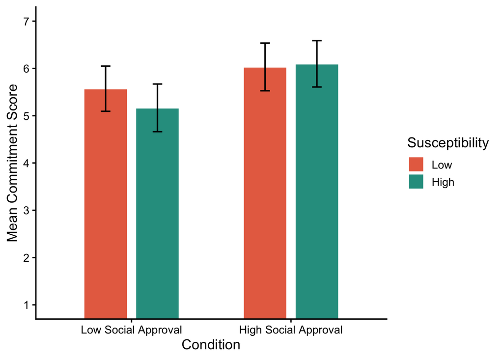

```r
p_commit_bar <- ggplot(
  as.data.frame(emmeans(a1_commit, ~ condition * suscep_msplit)),
  aes(
    x = condition,
    y = emmean,
    fill = suscep_msplit
  )
) +
  geom_col(
    position = position_dodge(width = 0.65),
    width = 0.55,
    color = "white"
  ) +
  geom_errorbar(
    aes(
      ymin = lower.CL,
      ymax = upper.CL
    ),
    position = position_dodge(width = 0.65),
    width = 0.12,
    linewidth = 0.7
  ) +
  labs(
    x = "Condition",
    y = "Mean Commitment Score",
    fill = "Susceptibility"
  ) +
  scale_fill_manual(
    values = c(
      "Low" = "#E76F51",  # YOU CAN CHANGE THESE TWO HEX VALUES TO MATCH YOUR POSTER!
      "High" = "#2A9D8F"
    )
  ) +
  scale_y_continuous(
    breaks = 1:7
  ) +
  coord_cartesian(
    ylim = c(1, 7)
  ) +
  theme_classic(
    base_size = 14
  )

p_commit_bar
```

This plot shows model-estimated mean commitment scores across social approval condition, shown separately for participants low and high in susceptibility. Error bars represent 95% confidence intervals.

### Satisfaction Interaction Plot

This plot shows model-estimated mean relationship satisfaction scores across social approval condition for participants low and high in susceptibility.

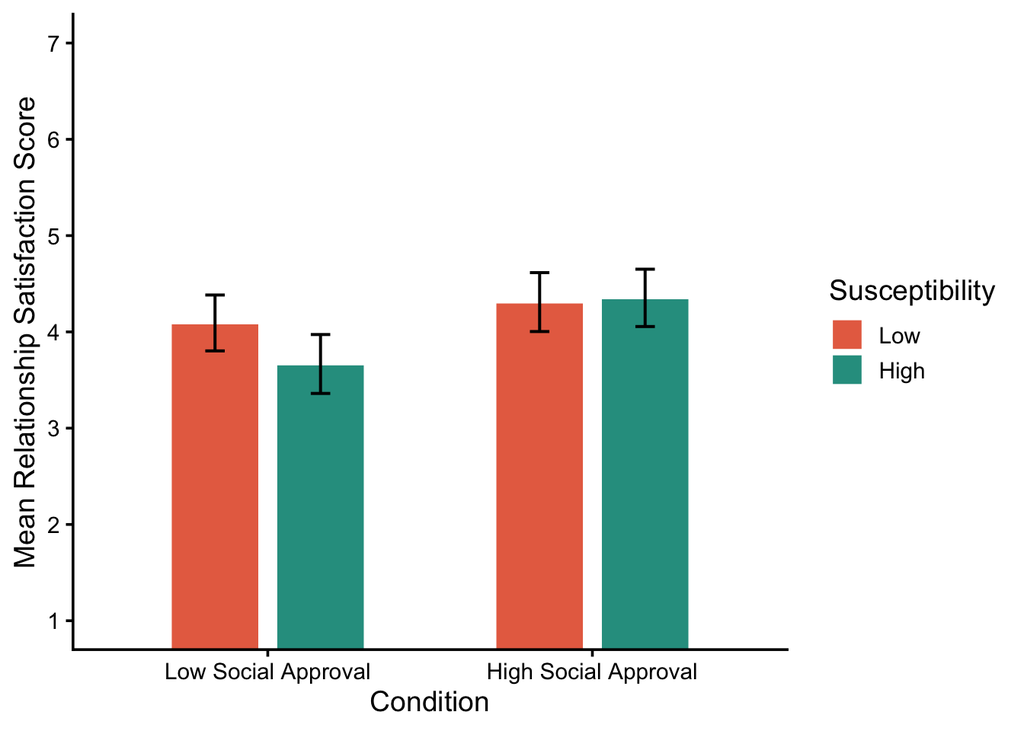

```r
p_ras_bar <- ggplot(
  as.data.frame(emmeans(a1_ras, ~ condition * suscep_msplit)),
  aes(
    x = condition,
    y = emmean,
    fill = suscep_msplit
  )
) +
  geom_col(
    position = position_dodge(width = 0.65),
    width = 0.55,
    color = "white"
  ) +
  geom_errorbar(
    aes(
      ymin = lower.CL,
      ymax = upper.CL
    ),
    position = position_dodge(width = 0.65),
    width = 0.12,
    linewidth = 0.7
  ) +
  labs(
    x = "Condition",
    y = "Mean Relationship Satisfaction Score",
    fill = "Susceptibility"
  ) +
  scale_fill_manual(
    values = c(
      "Low" = "#E76F51",  # YOU CAN CHANGE THESE TWO HEX VALUES TO MATCH YOUR POSTER!
      "High" = "#2A9D8F"
    )
  ) +
  scale_y_continuous(
    breaks = 1:7
  ) +
  coord_cartesian(
    ylim = c(1, 7)
  ) +
  theme_classic(
    base_size = 14
  )

p_ras_bar
```

This plot shows model-estimated mean relationship satisfaction scores across social approval condition, shown separately for participants low and high in suceptibility. Error bars represent 95% confidence intervals.

### Export Figures

```r
if (!dir.exists("figures")) {
  dir.create("figures")
}

ggsave(
  filename = "figures/commitment_interaction_plot.svg",
  plot = p_commit_bar,
  width = 7,
  height = 5
)

ggsave(
  filename = "figures/satisfaction_interaction_plot.svg",
  plot = p_ras_bar,
  width = 7,
  height = 5
)
```

Above is saving the figures for exporting.

## Results Summary

The results of the 2x2 ANOVA analyses indicates a moderate effect of social approval on relationship commitment, with significantly more levels of relationship commitment when individuals were in the high approval condition compared to those in the low condition. We found a negligible effect of susceptibility to interpersonal influence on relationship commitment. As well as that the effect of social approval on relationship commitment does not depend on susceptibility level.

Additionally, we concluded that there is a moderate effect of social approval on relationship satisfaction, with significantly more levels of relationship satisfaction when individuals were in the high approval condition compared to those in the low approval condition. We found that there is a negligible effect of susceptibility to interpersonal influence on relationship satisfaction. Lastly, we concluded that the effect of social approval on relationship satisfaction does not depend on susceptibility to interpersonal influence.